# Albanese et al. (2016) estimation of stature

Lyle W. Konigsberg

2024-10-15

```r
library(C.Ruff)
```

We will first do the default call to “A_run” which uses the femur equation from Albanese et al. (2016) and applies it to the “European” data set from Ruff (2018). See “European data set: Excel” and “Notes” under “Special Projects” [here](https://fae.johnshopkins.edu/chris-ruff/).

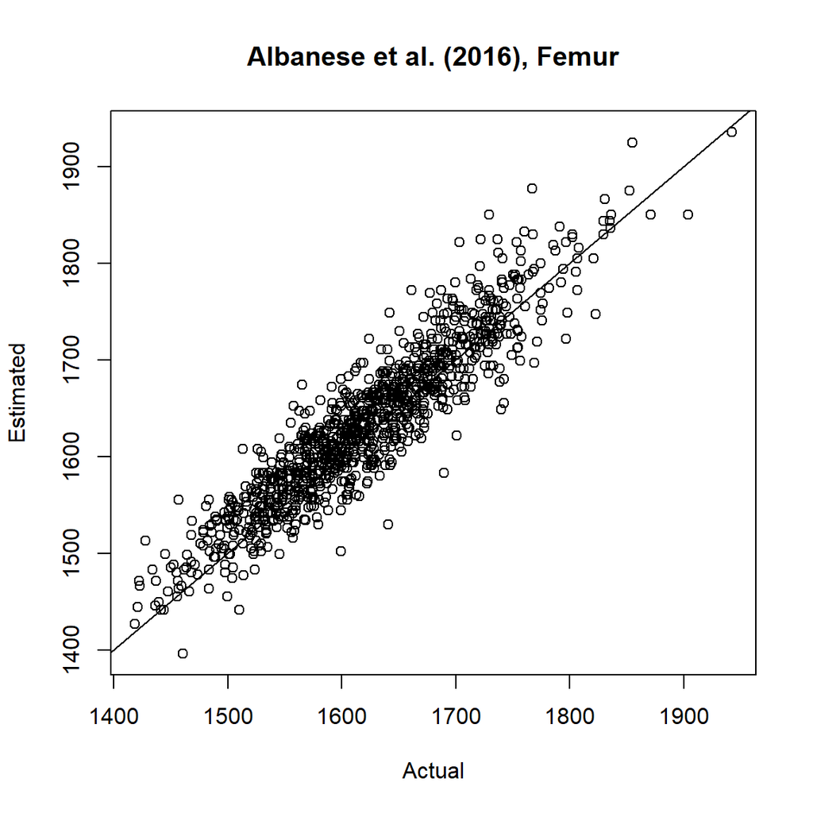

```
#> mean bias =   13.20019
#>
#> mean bias bottom quartile =   18.26053
#> Number actual below 50% PI, Number actual in 50% PI, Number actual above 50% PI
#> Bottom quartile  85 167 14
#>
#> mean bias middle half =   11.32987
#> Middle half  139 339 51
#>
#> mean bias top quartile =   11.86442
#> Top quartile  70 172 25
#>
#>  All data
#> 294 678 90
```

```r
A_run()
```

Let’s see for the total data set whether the proportion of cases in the 50 percent prediction interval actually contains 50 percent of the data. That is a straight-forward binomial test:

```r
sto=294+678+90
print(sto)
```

```
#> [1] 1062
```

```r
print(binom.test(678,sto,0.5))
```

```
#>
#>  Exact binomial test
#>
#> data:  678 and sto
#> number of successes = 678, number of trials = 1062, p-value < 2.2e-16
#> alternative hypothesis: true probability of success is not equal to 0.5
#> 95 percent confidence interval:
#>  0.6086989 0.6673676
#> sample estimates:
#> probability of success
#>              0.6384181
```

OK, not so good. The probability value is quite low, because the 95% confidence interval for the proportion in the 50% prediction interval is from about 0.6087 to 0.6674. It is even worse if we compare the proportion of cases below the 50% PIs to the total of those above and those below.

```r
sto=294+90
print(sto)
```

```
#> [1] 384
```

```r
print(binom.test(294,sto,0.5))
```

```
#>
#>  Exact binomial test
#>
#> data:  294 and sto
#> number of successes = 294, number of trials = 384, p-value < 2.2e-16
#> alternative hypothesis: true probability of success is not equal to 0.5
#> 95 percent confidence interval:
#>  0.7199948 0.8071064
#> sample estimates:
#> probability of success
#>               0.765625
```

OK, so that shows that the bulk of the cases (actual statures) are below the 50% PIs. We would have expected about half should be below and half should be above. But, that is not happening because the estimated statures are biased. Generally, the estimates are greater than the actual statures, as in the plot.

Now let’s use the female Iberian data and the humerus.

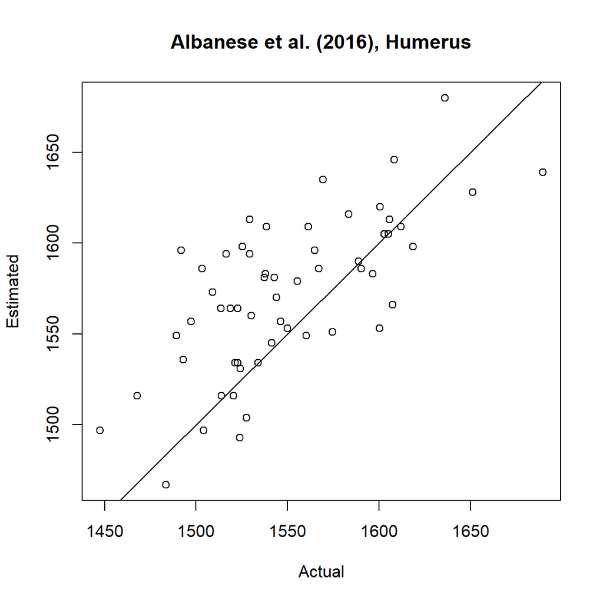

```
#> mean bias =   22.14737
#>
#> mean bias bottom quartile =   29.17857
#> Number actual below 50% PI, Number actual in 50% PI, Number actual above 50% PI
#> Bottom quartile  6 8 0
#>
#> mean bias middle half =   18.25714
#> Middle half  11 15 2
#>
#> mean bias top quartile =   22.84667
#> Top quartile  6 8 1
#>
#>  All data
#> 23 31 3
```

```r
A_run(i.which="Hum",which.dat=3)
```

```r
sto=23+31+3
print(sto)
```

```
#> [1] 57
```

```r
print(binom.test(23,sto,0.5))
```

```
#>
#>  Exact binomial test
#>
#> data:  23 and sto
#> number of successes = 23, number of trials = 57, p-value = 0.1849
#> alternative hypothesis: true probability of success is not equal to 0.5
#> 95 percent confidence interval:
#>  0.2756127 0.5417866
#> sample estimates:
#> probability of success
#>              0.4035088
```

```r
sto=23+3
print(sto)
```

```
#> [1] 26
```

```r
print(binom.test(23,sto,0.5))
```

```
#>
#>  Exact binomial test
#>
#> data:  23 and sto
#> number of successes = 23, number of trials = 26, p-value = 8.798e-05
#> alternative hypothesis: true probability of success is not equal to 0.5
#> 95 percent confidence interval:
#>  0.6984596 0.9755419
#> sample estimates:
#> probability of success
#>              0.8846154
```

Terrible! The Albanese et al. (2016) equation is clearly overestimating stature. This is not suprising, as on the overall dataset there was overestimation, and the Iberian females have one of the lowest average statures of any of the regional groups…

```r
attach(Europe)
sto=aggregate(Stat~Sex*Region,FUN=mean)
Ord=sort(sto$Stat,index.ret=T)$ix
print(sto[Ord,])
```

```
#>       Sex         Region     Stat
#> 5  Female         France 1549.047
#> 7  Female         Iberia 1549.923
#> 9  Female          Italy 1552.052
#> 3  Female        Britain 1567.930
#> 11 Female N.-Cen. Europe 1570.839
#> 13 Female Scand./Finland 1577.462
#> 1  Female        Balkans 1598.446
#> 6    Male         France 1631.342
#> 10   Male          Italy 1637.968
#> 8    Male         Iberia 1648.143
#> 4    Male        Britain 1654.328
#> 12   Male N.-Cen. Europe 1666.523
#> 14   Male Scand./Finland 1680.695
#> 2    Male        Balkans 1699.088
```

…while still having an appreciable sample size

```r
print(table(data.frame(Sex,Region)))
```

```
#>         Region
#> Sex      Balkans Britain France Iberia Italy N.-Cen. Europe Scand./Finland
#>   Female      24     115     36     57    46             69            108
#>   Male        25     125     48     72    71            112            154
```

#### References

Albanese, John, Andrew Tuck, José Gomes, and Hugo FV Cardoso. 2016. “An Alternative Approach for Estimating Stature from Long Bones That Is Not Population-or Group-Specific.” Journal Article. *Forensic Science International* 259: 59–68.

Ruff, Christopher. 2018. *Skeletal Variation and Adaptation in Europeans : Upper Paleolithic to the Twentieth Century*. Book. Hoboken, NJ: Wiley Blackwell. https://doi.org/10.1002/9781118628430.